# Laboratorio 2

Joshua Cervantes

07 June 2022

# Ejercicio 1

Considere la tabla ilustrativa del Bowers utilizada en este curso, se realiza un ejercicio para calcular el valor presente actuarial de un seguro temporal que paga 1 unidad al final del año ede muerte o fallo del sistema, considerando dos vidas $x$ y $y$, y los estados de vida individuales, vida conjunta y último sobreviviente. Se utiliza una tasa de 6% anual.

```r
# Se va usar la misma tabla para ambos ejercicios
px <- tabla$lx[-1] / tabla$lx[-length(tabla$lx)]
px[length(px) + 1] <- 0


# Se genera una tabla de sobrevivencia a partir de las probabilidades calculadas
life_table <- probs2lifetable(px, type = "px")
```

1. Se parte de edades iniciales denotadas por $x_1=30$ $y_1=40$, y se determinan vectores con los valores del seguro temporal a $n=1,2,..,80$ años respectivamente (en algunos casos sería de vida completo).

```r
# Se estiman los seguros
# nAx es seguro de una vida temporal a n edad x
# nAx_y temporal a n conjunta
# nA_x_y temporal a n ultimo sobreviviente
# Tabla de vida de dos vida
life_table_b <- list(life_table, life_table)

interest <- 0.06
n <- 1:80
x1 <- 30
x2 <- 40
nA30 <- numeric()
nA40 <- numeric()
nA30_40 <- numeric()
nA_30_40 <- numeric()
for (i in n) {
    nA30[i] <- Axn(life_table, n = i, i = interest, x = x1)
    nA40[i] <- Axn(life_table, n = i, i = interest, x = x2)
    nA30_40[i] <- Axyzn(life_table_b, x = c(x1, x2), n = i, i = interest, status = "joint")
    nA_30_40[i] <- Axyzn(life_table_b, x = c(x1, x2), n = i, i = interest, status = "last")
}
```

**Figura 1: Valor de los seguros, según tiempo de cobertura.**

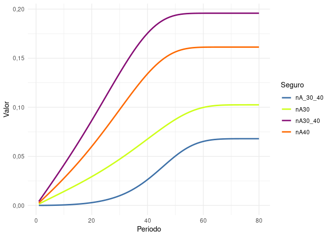

```r
# Se grafica
insurance_n <- data.frame("n" = n, nA30, nA40, nA30_40, nA_30_40)
insurance_n <- insurance_n %>% gather("Seguro", "Valor", 2:ncol(insurance_n))
insurance_n %>% ggplot(aes(x = n, y = Valor, color = Seguro)) +
    geom_line(size = 1) +
    scale_color_jcolors(palette = "pal2") +
    theme_minimal() +
    labs(x = "Periodo", y = "Valor")
```

2. Determine el valor $A_{30:40}$ y $A_{\overline{30:40}}$ de forma determinística y estocástica.

**Deterministico**

```r
# Se procede a determinar el valor de los seguro pero vitalicios

# Deterministico

# Vida conjunta
A30_40 <- Axyzn(life_table_b, x = c(x1, x2), i = interest, status = "joint")

# Ultimo sobreviviente
A_30_40 <- Axyzn(life_table_b, x = c(x1, x2), i = interest, status = "last")
```

```r
# Seguro vida conjunta deterministico
A30_40
```

```
## [1] 0,19584
```

```r
# Seguro vida ultimo sobreviviente deterministico
A_30_40
```

```
## [1] 0,067967
```

El valor de los reguros es
$$A_{30:40}=0,19584 \qquad A_{\overline{30:40}}=0,067967$$

**Estocástico**

```r
## Simulaciones
simulations <- 50000

# Tiempo de vida cada individuo
T30 <- rLife(simulations, life_table, x = 30) + 0.5
T40 <- rLife(simulations, life_table, x = 40) + 0.5


# Tiempo vida conjunta
T30_40 <- unlist(mapply(FUN = min, T30, T40))

# Tiempo de vida ultimo sobreviviente
T_30_40 <- unlist(mapply(FUN = max, T30, T40))

# Se procede a calcular el valor de lo seguros
v <- 1 / (1 + interest)
d <- 1 - v
# Primero se crean los valores presentes de las simulaciones
vT30_s <- v^(T30)
vT40_s <- v^(T40)
vT30_40_s <- v^(T30_40)
vT_30_40_s <- v^(T_30_40)


A30_s <- sum(vT30_s / simulations)
A40_s <- sum(vT40_s / simulations)
A30_40_s <- sum(vT30_40_s / simulations)
A_30_40_s <- sum(vT_30_40_s / simulations)
```

```r
# Vida conjunta estocastico
A30_40_s
```

```
## [1] 0,19592
```

```r
# Ultimo sobreviviente estocastico
A_30_40_s
```

```
## [1] 0,067881
```

Entonces se obtiene
$$A_{30:40}=0,19592 \qquad A_{\overline{30:40}}=0,067881$$
c. Se grafica el histograma de las realizaciones del seguro.

**Figura 2: Distribución de los beneficios futuros.**

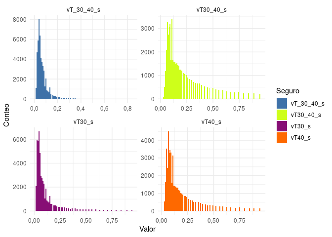

```r
# En este caso se procede  grafica
distribution <- data.frame(vT30_s, vT40_s, vT30_40_s, vT_30_40_s)
distribution <- distribution %>% gather("Seguro", "Valor_de_las_simulaciones", 1:ncol(distribution))
distribution %>% ggplot(aes(x = Valor_de_las_simulaciones, fill = Seguro)) +
    geom_histogram(bins = 100) +
    facet_wrap(~Seguro, scales = "free") +
    scale_fill_jcolors(palette = "pal2") +
    theme_minimal() +
    labs(x = "Valor", y = "Conteo")
```

# Ejercicio 2

Considere la tabla ilustrativa del Bowers utilizada en este curso, se realiza un ejercicio para calcular el valor presente actuarial de una anualidad temporal que paga 1 unidad al inicio del periodo mientras el estado permanezca activo, considerando dos vidas $x$ y $y$, y los estados de vida individuales, vida conjunta y último sobreviviente. Se utiliza una tasa del 6% anual.

1. Se parte de edades iniciales denotadas por $x_1=30$ y $y_1=40$, y se determinan los vectores con valores de anualidad temporal a $n=1,2,...,80$ años respectivamente (en algunos casos sería de vida completo).

**Figura 3: Valor de la anualidades, según tiempo de duración.**

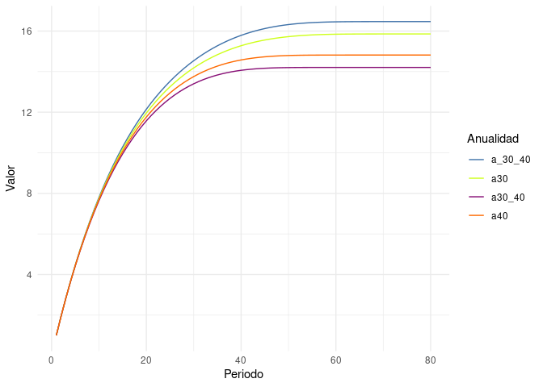

```r
# Se procede a estimar cada uno de los valores para los seguros de acuerdo a cada temporalidad
a30 <- numeric()
a40 <- numeric()
a30_40 <- numeric()
a_30_40 <- numeric()

for (i in 1:80) {
    a30[i] <- axn(life_table, x = 30, n = i, i = interest)
    a40[i] <- axn(life_table, x = 40, n = i, i = interest)
    a30_40[i] <- axyzn(life_table_b, x = c(30, 40), i = interest, n = i, status = "joint")
    a_30_40[i] <- axyzn(life_table_b, x = c(30, 40), i = interest, n = i, status = "last")
}
annuities <- data.frame(Temporalidad = 1:80, a30, a40, a30_40, a_30_40)
annuities <- annuities %>% gather("Anualidad", "Valor", 2:ncol(annuities))
annuities %>% ggplot(aes(x = Temporalidad, y = Valor, color = Anualidad)) +
    geom_line() +
    scale_color_jcolors(palette = "pal2") +
    theme_minimal() +
    labs(x = "Periodo", y = "Valor")
```

2. Determine el valor $a_{30:40}$ y $a_{\overline{30:40}}$ de forma determinística y estocástica.

## Determinístico

```r
# Vida conjunta
a30_40_d <- axyzn(life_table_b, x = c(30, 40), i = interest, status = "joint")
# Ultimo sobreviviente
a_30_40_d <- axyzn(life_table_b, x = c(30, 40), i = interest, status = "last")

# Vida conjunta
a30_40_d
```

```
## [1] 14,207
```

```r
# Ultimo sobreviviente
a_30_40_d
```

```
## [1] 16,466
```

Los resultados son
$$\ddot{a}_{30:40}=14,207 \qquad \ddot{a}_{\overline{30:40}}=16,466$$

## Estocástico

```r
T30 <- rLife(simulations, life_table, x = 30) + 0.5
T40 <- rLife(simulations, life_table, x = 40) + 0.5


# Tiempo vida conjunta
T30_40 <- unlist(mapply(FUN = min, T30, T40))

# Tiempo de vida ultimo sobreviviente
T_30_40 <- unlist(mapply(FUN = max, T30, T40))
# Vida conjunta
a30_40_s <- sum((1 - v^T30_40) / (1 - v)) / simulations

# Ultimo sobreviviente
a_30_40_s <- sum((1 - v^T_30_40) / (1 - v)) / simulations


# Vida conjunta
a30_40_s
```

```
## [1] 14,232
```

```r
# Ultimo sobreviviente
a_30_40_s
```

```
## [1] 16,467
```

Entonces se obtiene como resultado
$$\ddot{a}_{30:40}=14,232 \qquad \ddot{a}_{\overline{30:40}}=16,467$$

3. Se grafica el histograma de las realizaciones de la anualidad.

**Figura 4: Distribución de los anualidades.**

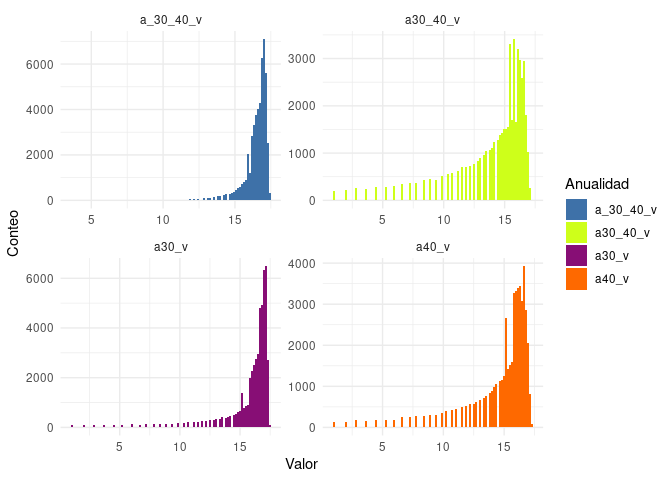

```r
# Valores de las simulaciones
# Vidas individuales
a30_v <- (1 - v^T30) / d
a40_v <- (1 - v^T40) / d
## Vida conjunta
a30_40_v <- (1 - v^T30_40) / (1 - v)
## Ultimo sobreviviente
a_30_40_v <- (1 - v^T_30_40) / (1 - v)
distribution_axy <- data.frame(a30_40_v, a_30_40_v, a30_v, a40_v)
distribution_axy <- distribution_axy %>% gather("Anualidad", "Valor_de_las_simulaciones", 1:ncol(distribution_axy))
distribution_axy %>% ggplot(aes(x = Valor_de_las_simulaciones, fill = Anualidad)) +
    geom_histogram(bins = 100) +
    facet_wrap(~Anualidad, scales = "free") +
    scale_fill_jcolors(palette = "pal2") +
    theme_minimal() +
    labs(x = "Valor", y = "Conteo")
```

d. Anualidad especial

Considera una anualidad vitalicia que se paga al inicio de cada año a razón de 1 unidad de prima si ambos inidividuos permanecen con vida y el otro ha fallecido ha fallecido. Se calcula el valor presente actuarial de anualidad bajo el método determinístico y el método estocástico.

## Determinístico

```r
# Anualidad especial
# Deterministico
a30_40_sp <- 1 / 3 * axyzn(life_table_b, x = c(30, 40), i = interest, status = "joint") + 2 / 3 * axyzn(life_table_b, x = c(30, 40), i = interest, status = "last")

a30_40_sp
```

```
## [1] 15,713
```

## Estocástico

```r
a30_40_sp_s <- (1 - v^(T30_40)) / d + 2 / 3 * (v^T30_40 - v^T_30_40) / d
```

```r
# Seguro de vida especial
mean(a30_40_sp_s)
```

```
## [1] 15,722
```

5. Se grafica el histograma de las realizaciones de la anualidad especial.

**Figura 5: Distribución anualidad especial.**

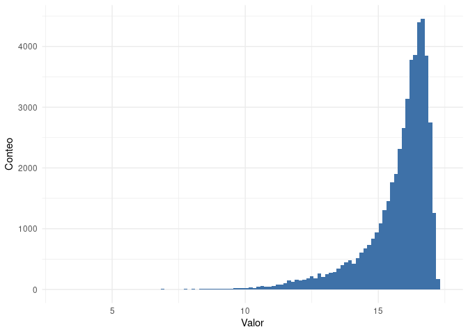

```r
axy_sp <- data.frame(a30_40_sp_s)
axy_sp %>% ggplot(aes(x = a30_40_sp_s, fill = "")) +
    geom_histogram(bins = 100, show.legend = FALSE) +
    scale_fill_jcolors(palette = "pal2") +
    theme_minimal() +
    labs(x = "Valor", y = "Conteo")
```

# Ejercicio 3

1. Se estiman los valores de prima neta bajo el principio de equivalencia, y contemplando ambos enfoques: determinísticos y estocástico.

## Deterministico

```r
# Vidas individuales
p30 <- Axn(life_table, i = interest, x = 30) / axn(life_table, i = interest, x = 30)
p40 <- Axn(life_table, i = interest, x = 40) / axn(life_table, i = interest, x = 40)

# Vida conjunta
p30_40 <- A30_40 / axyzn(life_table_b, x = c(30, 40), i = interest, status = "joint")

## Ultimo sobreviviente
p_30_40 <- A_30_40 / axyzn(life_table_b, x = c(30, 40), i = interest, status = "last")
```

```r
# Prima seguro individual 30 años
p30
```

```
## [1] 0,0064633
```

```r
# Prima seguro individual 40 años
p40
```

```
## [1] 0,010888
```

```r
# Prima seguro vida conjunta
p30_40
```

```
## [1] 0,013785
```

```r
# Prima seguro ultimo sobreviviente
p_30_40
```

```
## [1] 0,0041277
```

## Estocástico

```r
# Vida individuales
p30_s <- vT30_s / a30_v
p40_s <- vT40_s / a40_v
# Vida conjunta
p30_40_s <- vT30_40_s / a30_40_v

## Ultimo sobreviviente
p_30_40_s <- vT_30_40_s / a_30_40_v
```

```r
# Prima seguro individual 30 años
mean(p30_s)
```

```
## [1] 0,0069315
```

```r
# Prima seguro individual 40 años
mean(p40_s)
```

```
## [1] 0,01208
```

```r
# Prima seguro vida conjunta
mean(p30_40_s)
```

```
## [1] 0,015891
```

```r
# Prima seguro ultimo sobreviviente
mean(p_30_40_s)
```

```
## [1] 0,0041396
```

2. Se grafica el histograma de las realizaciones de la prima.

**Figura 6: Distribución de las primas.**

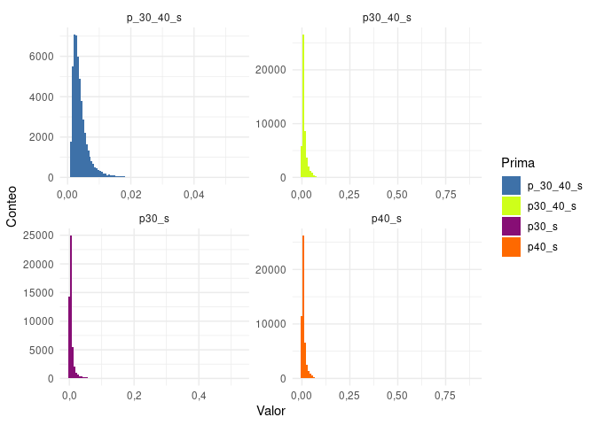

```r
distribution_pxy <- data.frame(p30_40_s, p_30_40_s, p30_s, p40_s)
distribution_pxy <- distribution_pxy %>% gather("Prima", "Valor_de_las_simulaciones", 1:ncol(distribution_pxy))

distribution_pxy %>% ggplot(aes(x = Valor_de_las_simulaciones, fill = Prima)) +
    geom_histogram(bins = 100) +
    facet_wrap(~Prima, scales = "free") +
    scale_fill_jcolors(palette = "pal2") +
    theme_minimal() +
    labs(x = "Valor", y = "Conteo")
```

# Preguntas

- Suponga que la aseguradora espera una reducción en la mortalidad debido a que asegura una población con poder adquisitivo más alto que la media poblacional, por lo que considera la reducción en el riesgo en el percentil 45% de la distribución de beneficios futuros bajo el enfoque estocástico, ¿Cúal sería el valor de la nueva prima neta (de riesgo)?

```r
# Tomando solo el cuantil 45 de la distribucion de beneficios futuros se cumple

# Vidas independientes
quan <- quantile(vT30_s, 0.45)
p30 <- vT30_s[vT30_s <= quan]
p30 <- mean(p30) / mean(a30_v)
quan <- quantile(vT40_s, 0.45)
p40 <- vT40_s[vT40_s <= quan]
p40 <- mean(p40) / mean(a40_v)

# Vida conjunta
quan <- quantile(vT30_40_s, 0.45)
p30_40 <- vT30_40_s[vT30_40_s <= quan]
p30_40 <- mean(p30_40) / a30_40_s

# Ultimo sobreviviente

quan <- quantile(vT_30_40_s, 0.45)
p_30_40 <- vT_30_40_s[vT_30_40_s <= quan]
p_30_40 <- mean(p_30_40) / a_30_40_s
```

```r
# Vida de edad 30
p30
```

```
## [1] 0,0024533
```

```r
# Vida de edad 40
p40
```

```
## [1] 0,004513
```

```r
# Vida conjunta
p30_40
```

```
## [1] 0,0059116
```

```r
# Ultimo sobreviviente
p_30_40
```

```
## [1] 0,0022433
```

- Con base en el enfoque estocástico, ¿Cuál es la probabilidad de que el valor presente de las primas efectivamente pagadas sea menor a la mitad del valor presente acturial de la anualidad?, esto para cada modelo de múltiples vidas.

```r
## Para esto vamos a utilizar la distribucion empirica de la anualidad
## Para este ejercicio se tomará en cuenta las realizaciones de las anualidades
# Vidas independientes

probability_30 <- a30_v[a30_v <= mean(a30_v) / 2]
probability_30 <- length(probability_30) / length(a30_v)


probability_40 <- a40_v[a30_v <= mean(a40_v) / 2]
probability_40 <- length(probability_40) / length(a40_v)

# Vida conjunta
probability30_40 <- a30_40_v[a30_40_v <= mean(a30_40_v) / 2]
probability30_40 <- length(probability30_40) / length(a30_40_v)

# Ultimo sobreviviente
probability_30_40 <- a_30_40_v[a30_40_v <= mean(a_30_40_v) / 2]
probability_30_40 <- length(probability_30_40) / length(a_30_40_v)
```

```r
# Probabilidad vida individual 30 años
probability_30
```

```
## [1] 0,01954
```

```r
# Probabilidad vida individual 40 años
probability_40
```

```
## [1] 0,01716
```

```r
# Probabilidad vida conjunta
probability30_40
```

```
## [1] 0,04196
```

```r
# Probabilida último sobreviviente
probability_30_40
```

```
## [1] 0,05692
```

- ¿Cuál debería ser la prima neta pagadas en la anualidad respectiva si se desea un nivel de confianza del 85%, 90% y 95%, respectivamente?, conforme una tabla de valores.

```r
# Para 85% se estimane el cuantil 15/2% y 1-15/2% de los beneficios a pagar
# Caso individual

## Para este ejercicio se tomará las distribución de las realizaciones de las primas y se le estimarán los intervalos de confianza tomando los cuantiles
quantiles <- c(0.15, 0.10, 0.05)
table <- data.frame("Confianza" = character(), p30 = numeric(), p40 = numeric(), p30_40 = numeric(), p_30_40 = numeric())

for (i in quantiles) {

    # Vidas independientes
    quan1 <- quantile(p30_s, i / 2)
    quan2 <- quantile(p30_s, 1 - i / 2)
    p30 <- p30_s[p30_s >= quan1 & p30_s <= quan2]
    print(paste(length(p30), length(p30_s), sep = " "))
    p30 <- mean(p30)
    quan1 <- quantile(p40_s, i / 2)
    quan2 <- quantile(p40_s, 1 - i / 2)
    p40 <- p40_s[p40_s >= quan1 & p40_s <= quan2]
    print(paste(length(p40), length(p40_s), sep = " "))
    p40 <- mean(p40)
    # Vida conjunta
    quan1 <- quantile(p30_40_s, i / 2)
    quan2 <- quantile(p30_40_s, 1 - i / 2)

    p30_40 <- p30_40_s[p30_40_s >= quan1 & p30_40_s <= quan2]
    print(paste(length(p30_40), length(p30_40_s), sep = " "))
    p30_40 <- mean(p30_40)
    # Ultimo sobreviviente

    quan1 <- quantile(p_30_40_s, i / 2)
    quan2 <- quantile(p_30_40_s, 1 - i / 2)

    p_30_40 <- p_30_40_s[p_30_40_s >= quan1 & p_30_40_s <= quan2]
    print(paste(length(p_30_40), length(p_30_40_s), sep = " "))
    p_30_40 <- mean(p_30_40)

    aux <- data.frame("Confianza" = paste((1 - i) * 100, "%"), p30 = p30, p40 = p40, p30_40 = p30_40, p_30_40 = p_30_40)
    table <- rbind(table, aux)
}
```

```
## [1] "42531 50000"
## [1] "42515 50000"
## [1] "42515 50000"
## [1] "42522 50000"
## [1] "45010 50000"
## [1] "45010 50000"
## [1] "45004 50000"
## [1] "45004 50000"
## [1] "47503 50000"
## [1] "47503 50000"
## [1] "47509 50000"
## [1] "47527 50000"
```

```r
kable(table,
    col.names = c(
        "Nivel de confianza",
        "Prima $A_{30}$",
        "Prima $A_{40}$",
        "Prima $A_{30:40}$",
        "Prima $A_{\\overline{30:40}}$"
    ),
    caption = "Resultados", format.args = list(decimal.mark = ",", big.mark = "."), escape = FALSE
) %>%
    kable_styling(full_width = F) %>%
    kable_material() %>%
    row_spec(0, bold = T, color = "white", background = "#159957") %>%
    scroll_box(height = "300px", width = "100%")
```

Resultados

| Nivel de confianza | Prima $A_{30}$ | Prima $A_{40}$ | Prima $A_{30:40}$ | Prima $A_{\overline{30:40}}$ |
| --- | --- | --- | --- | --- |
| 85 % | 0,00507 | 0,00942 | 0,01240 | 0,00367 |
| 90 % | 0,00539 | 0,00988 | 0,01299 | 0,00375 |
| 95 % | 0,00586 | 0,01053 | 0,01375 | 0,00387 |

2. Realice el ejercicio 3 (sin las preguntas adicionales) considerando para las anualidades los mismos vectores Txs y Txy utilizados para los seguros, es decir, no generar unos nuevos para las anualidades. Detalle que sucede con las primas bajos los enfoques determinístico y estocástico en ambos modelo de múltiples vidas. ¿Porqué sucede lo observado?.

```r
# Vidas individuales
T30 <- rLife(simulations, life_table, x = 30) + 0.5
T40 <- rLife(simulations, life_table, x = 40) + 0.5

# Vida conjumta
T30_40 <- mapply(FUN = min, T30, T40)

# Ultimo sobreviviente
T_30_40 <- mapply(FUN = max, T30, T40)

# Seguro vida conjunta
A30_40 <- v^T30_40

# Seguro ultimo sobreviviente
A_30_40 <- v^T_30_40


# Anualidad vida conjunta
a30_40 <- (1 - v^T30_40) / d
a_30_40 <- (1 - v^T_30_40) / d
```

```r
# Prima vida conjunta
prima30_40_s <- A30_40 / a30_40
mean(prima30_40_s)
```

```
## [1] 0,02422
```

```r
# Prima ultimo sobreviviente
prima_30_40_s <- A_30_40 / a_30_40

mean(prima_30_40_s)
```

```
## [1] 0,0043634
```

Se procede a graficar las realizaciones de las prima

**Figura 7: Distribución de las primas.**

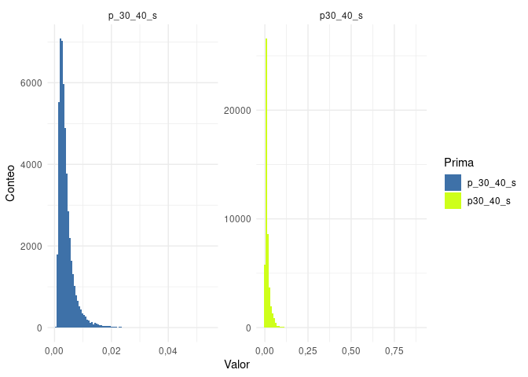

```r
distribution_pxy <- data.frame(p30_40_s, p_30_40_s)
distribution_pxy <- distribution_pxy %>% gather("Prima", "Valor_de_las_simulaciones", 1:ncol(distribution_pxy))

distribution_pxy %>% ggplot(aes(x = Valor_de_las_simulaciones, fill = Prima)) +
    geom_histogram(bins = 100) +
    facet_wrap(~Prima, scales = "free") +
    scale_fill_jcolors(palette = "pal2") +
    theme_minimal() +
    labs(x = "Valor", y = "Conteo")
```

**Análisis**

Se puede observar que la prima que sufre una mayor variación es la de vida conjunta esto se debe a que se está estableciendo que justamente en el último año donde se paga la prima coincide con el año en que el status falla. Esto no sucede en el caso en que se generan valores distintos para la anualidad y para el seguro.